# σ-convergence across countries

WDI 1960-2024 dispersion with a Kong-Phillips-Sul trend test; PWT 10.01 2000-2019 KPS (with factor removal) and Phillips-Sul log t tests

Published

October 29, 2026

# Introduction

**Note概要**

- 国別の一人当たりGDP（対数）の標準偏差σを年ごとに描き、σ収束が起きているかを見る。
- シミュレーションで「β収束あり・σ収束あり」と「β収束あり・σ収束なし」を比べ、所得分布の位置と広がりの変化を図示する。
- WDI（1960-2024）とPWT 10.01（2000-2019）で、KPS検定・Phillips-Sul log t検定・収束クラブ分析を行う。
- 結果:
  - WDI（GDP pc、84か国、1960-2024）: 発散 → 収束
    - σ: 1.37 (1960) → 1.70 (2000) → 1.65 (2024)
    - 分散: （1960-2024; ● 最大 2000年）
    - β: 1960-1999で発散（t = -2.01）、2000-2024で収束（t = 2.39、半減期314年）
    - KPS検定: 1960-1999で拡散（t = 26.4）、2000-2024で収束（t = -4.88）
  - PWT（ppp GDP pc、128か国、2000-2019）: 弱い収束
    - 分散: （2000-2019; ● 最大 2008年; 1.44〜1.58）
    - β収束はあるが遅い（b = 0.0039、半減期172年 [差が1/2になるのに172年かかる]）。
    - KPS検定: σ収束（t = -5.29）。ただし分散は2008年まで拡大し、その後縮小。共通ファクターを除くとσ収束は認められない（t = -0.32 〜 0.20）。
    - Phillips-Sul検定: 全体の収束は棄却（t = -33.8）。
  - 収束クラブ（参考）: 6グループと発散4か国。15時点しかなく検出力が低いため、「収束を棄却できない」程度の弱い証拠。

**NoteSummary**

- It reports a weak σ-convergence test in the spirit of Kong, Phillips & Sul (2019, *J. Econometrics*): regress the cross-section variance on a linear trend; a significantly negative slope (Newey-West HAC t ratio) indicates convergence.
- Data: World Bank WDI `NY.GDP.PCAP.KD` (GDP per capita, constant 2015 US$, market exchange rates), saved locally (`data/gdppc_usd.json`); nothing is downloaded.
- Caveats:
  - Constant US$ at market exchange rates, not PPP; PPP series start only in 1990.
  - Common factors are not removed before the test, as KPS recommend for trending panels; this treats all countries as loading equally on the world trend.
- Results:
  - WDI (GDP pc, 84 countries, 1960-2024): divergence → convergence.
    - σ: 1.37 (1960) → 1.70 (2000) → 1.65 (2024).
    - Variance: (1960-2024; ● peak 2000).
    - β: divergence in 1960-1999 (t = -2.01), convergence in 2000-2024 (t = 2.39, half-life 314 years).
    - KPS test: divergence in 1960-1999 (t = 26.4), convergence in 2000-2024 (t = -4.88).
  - PWT (ppp GDP pc, 128 countries, 2000-2019): weak convergence.
    - Variance: (2000-2019; ● peak 2008; range 1.44-1.58).
    - β-convergence, but slow (b = 0.0039, half-life 172 years [the gap takes 172 years to halve]).
    - KPS test: σ-convergence (t = -5.29), though the variance rises until 2008 and falls afterwards; no σ-convergence after removing common factors (t = -0.32 to 0.20).
    - Phillips-Sul test: convergence of the whole panel rejected (t = -33.8).
  - Convergence clubs (for reference): 6 groups and 4 divergent countries; with 15 regression points and low power, this is weak evidence.
- This page plots σ-convergence: the cross-country standard deviation of log GDP per capita, year by year.

**Code: load WDI GDP per capita; drop aggregates, oil producers and countries under 1 million**

```r
library(data.table)
library(ggplot2)
library(tinytable)
g <- "data/"
wdi <- function(f) as.data.table(jsonlite::fromJSON(paste0(g, f), flatten = TRUE)[[2]])
gdp <- wdi("gdppc_usd.json")[!is.na(value), .(iso3 = countryiso3code, year = as.integer(date), y = value)]
ctry <- wdi("country.json")[region.value != "Aggregates", .(iso3 = id)]   # drops World, regions, income groups
oil <- wdi("oil.json")[!is.na(value), .(r = mean(value)), by = .(iso3 = countryiso3code)][r >= 10, iso3]
pop <- readRDS("data/wdi_pop_2019_2024.rds")[year == 2019, .(iso3 = iso3c, pop)]
gdp <- gdp[iso3 %in% ctry$iso3 & year <= 2024]
# Sample rule (as in Patel, Sandefur & Subramanian 2021, Fig. A.5): drop oil producers
# (mean oil rents >= 10% of GDP) and countries under 1 million people (2019)
small <- pop[pop < 1e6, iso3]
gdp <- gdp[!(iso3 %in% c(oil, small))]
gdp[, ly := log(y)]
```

**Code: compute the yearly cross-country std and variance of log income for three samples**

```r
# Three samples: every country observed in a year (unbalanced); fixed sample observed every year
# 1960-2024; fixed sample observed every year 1990-2024
bal <- function(from) {
  yrs <- from:2024
  keep <- gdp[year %in% yrs, .N, by = iso3][N == length(yrs), iso3]
  gdp[iso3 %in% keep & year %in% yrs]
}
s_all <- gdp[, .(sigma = sd(ly), K = mean((ly - mean(ly))^2), n = .N), by = year]
s_60  <- bal(1960)[, .(sigma = sd(ly), K = mean((ly - mean(ly))^2), n = .N), by = year]
s_90  <- bal(1990)[, .(sigma = sd(ly), K = mean((ly - mean(ly))^2), n = .N), by = year]
s_all[, sample := sprintf("All available (n = %d-%d)", min(n), max(n))]
s_60[,  sample := sprintf("Fixed since 1960 (n = %d)", n[1])]
s_90[,  sample := sprintf("Fixed since 1990 (n = %d)", n[1])]
ss <- rbind(s_all, s_60, s_90)
```

# What σ-convergence looks like (simulated)

- σ-convergence: the spread of (log) incomes across economies shrinks over time.
- β-convergence: poorer economies grow faster than richer ones.
- The two can part ways: poor economies can grow faster while random shocks keep pushing incomes apart.

**NoteSimulation details**

- The simulation uses the model of the derivation page, $\ln y_{it} = a + (1-\beta_1)\ln y_{i,t-1} + u_{it}$, plus a common growth trend of 4% per year: catch-up $\beta_1 = 0.02$ per year (about BSM’s estimate, p. 227), independent shocks $u_{it}$ of standard deviation $\sigma_u$; 200 economies, 40 years; 12 of them drawn as lines.
  - Left: incomes start far apart ($\sigma_0 = 0.30$) and shocks are small ($\sigma_u = 0.03$): the spread falls.
  - Right: incomes start close together ($\sigma_0 = 0.15$) and shocks are larger ($\sigma_u = 0.06$): poor economies still grow faster, but the spread rises towards its steady state $\sigma^{*} = \sigma_u/\sqrt{1-(1-\beta_1)^2}$.

**Code: simulate 200 economies under two scenarios; plot income paths and σ_t**

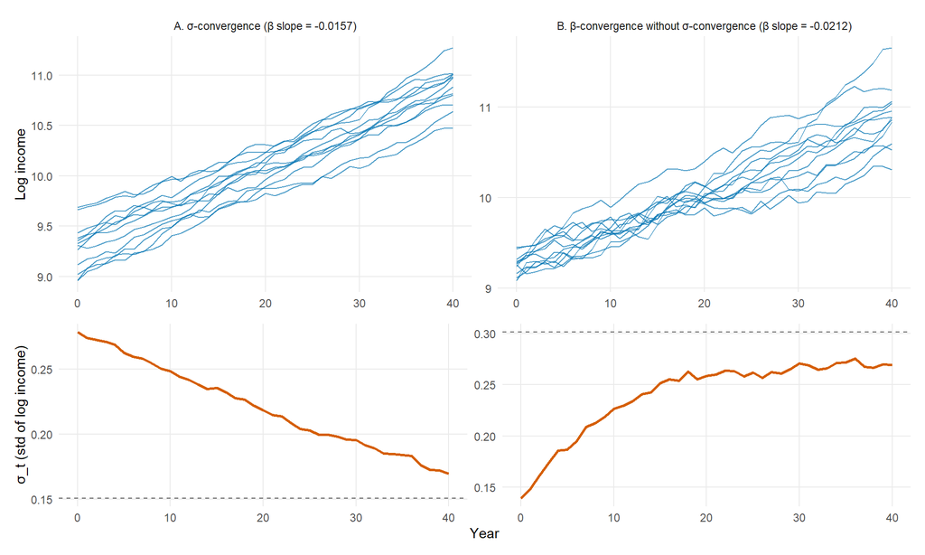

Figure 1: Simulated log incomes of 12 of 200 economies (top) and the cross-section standard deviation σ_t of all 200 (bottom). β-convergence holds in both panels (slope of 40-year average growth on initial log income is negative, shown in the panel titles); σ-convergence holds only on the left. Dashed line: steady-state σ*.

```r
sim <- function(sig0, sigu, b1 = 0.02, x = 0.04, N = 200, T = 40, a = 0.02 * log(10000), seed = 1) {
  set.seed(seed)
  y <- matrix(NA_real_, T + 1, N)
  y[1, ] <- log(10000) + rnorm(N, 0, sig0)                       # mean log income ~ log(10,000)
  for (t in 2:(T + 1)) y[t, ] <- a + (1 - b1) * y[t - 1, ] + rnorm(N, 0, sigu)
  y <- y + x * (0:T)                                              # common growth trend, x per year
  g <- (y[T + 1, ] - y[1, ]) / T                                  # average annual growth
  list(y = y, sd = apply(y, 1, sd), slope = coef(lm(g ~ y[1, ]))[2],
       sstar = sigu / sqrt(1 - (1 - b1)^2))
}
sc <- list(sim(0.30, 0.03), sim(0.15, 0.06))
lab <- c(sprintf("A. σ-convergence (β slope = %.4f)", sc[[1]]$slope),
         sprintf("B. β-convergence without σ-convergence (β slope = %.4f)", sc[[2]]$slope))
paths <- rbindlist(lapply(1:2, function(s) {
  d <- as.data.table(sc[[s]]$y[, 1:12]); d[, year := 0:40]
  d <- melt(d, id.vars = "year", variable.name = "econ", value.name = "ly"); d[, panel := lab[s]]
}))
sds <- rbindlist(lapply(1:2, function(s) data.table(year = 0:40, sd = sc[[s]]$sd, sstar = sc[[s]]$sstar, panel = lab[s])))
p1 <- ggplot(paths, aes(year, ly, group = econ)) +
  geom_line(colour = "#0072B2", alpha = 0.7, linewidth = 0.5) +
  facet_wrap(~panel, scales = "free_y") +
  labs(x = NULL, y = "Log income") +
  theme_minimal(base_size = 11) + theme(panel.grid.minor = element_blank())
p2 <- ggplot(sds, aes(year, sd)) +
  geom_line(colour = "#D55E00", linewidth = 1) +
  geom_hline(aes(yintercept = sstar), linetype = "dashed", colour = "grey40") +
  facet_wrap(~panel, scales = "free_y") +
  labs(x = "Year", y = "σ_t (std of log income)") +
  theme_minimal(base_size = 11) + theme(panel.grid.minor = element_blank(), strip.text = element_blank())
patchwork::wrap_plots(p1, p2, ncol = 1, heights = c(1.4, 1))
```

- In both panels the poorest economies grow fastest
  - Only panel A narrows the variance.
  - Dispersion falls only when the initial variance is greater than $\sigma^{*}$.

**Code: draw the model’s bell curves at years 0 and 40 for scenarios A and B (see below)**

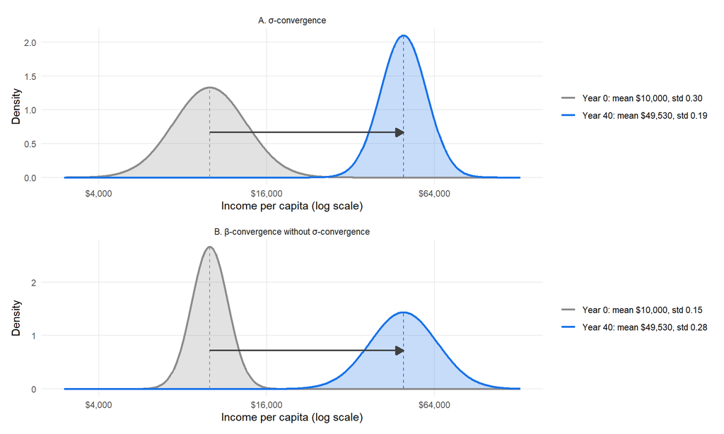

Figure 2: Model distribution of log income at years 0 and 40, with 4% common growth per year. Normal density with the model’s mean and std; dashed: mean. A: the bell moves right and narrows. B: it moves right and widens until it reaches σ*.

```r
pal4 <- c("#8c8c8c", "#8fa8c4", "#5a8fd0", "#1a73e8")         # mid gray (earliest) -> bright blue (latest)
bell <- function(s, xl) {
  grid <- seq(xl[1], xl[2], length.out = 600)
  d <- s[, .(ly = grid, dens = dnorm(grid, mu, s)), by = .(panel, when)]
  s[, lab := sprintf("%s: mean %s, std %.2f", when, scales::dollar(round(exp(mu), -1)), s)]
  cols <- if (nlevels(s$when) == 2) pal4[c(1, 4)] else pal4
  s <- s[order(when)]
  arr <- data.table(x0 = s$mu[1], x1 = s$mu[nrow(s)], y = 0.5 * min(dnorm(0, 0, s$s)))  # first mean -> last mean
  ggplot(d, aes(ly, dens, colour = when)) +
    geom_area(aes(fill = when), alpha = 0.25, position = "identity", colour = NA) +
    geom_line(linewidth = 1) +
    geom_segment(data = s, aes(x = mu, xend = mu, y = 0, yend = dnorm(0, 0, s), colour = when),
                 linetype = "dashed", linewidth = 0.5) +
    geom_segment(data = arr, aes(x = x0, xend = x1, y = y, yend = y), inherit.aes = FALSE,
                 colour = "grey25", linewidth = 0.8, arrow = arrow(length = unit(0.3, "cm"), type = "closed")) +
    facet_wrap(~panel, ncol = 1) +
    scale_fill_manual(values = cols, guide = "none") +
    scale_colour_manual(values = cols, labels = s[, lab], name = NULL) +
    scale_x_continuous(breaks = log(c(250, 1000, 4000, 16000, 64000)),
                       labels = scales::dollar(c(250, 1000, 4000, 16000, 64000)), limits = xl) +
    labs(x = "Income per capita (log scale)", y = "Density") +
    theme_minimal(base_size = 11) + theme(panel.grid.minor = element_blank())
}
yrs_h <- c(0, 40)
b1 <- 0.02; x <- 0.04                                            # catch-up 2% (BSM); common growth 4%
pars <- data.table(panel = sub(" \\(.*", "", lab), sig0 = c(0.30, 0.15), sigu = c(0.03, 0.06))
pars[, sstar := sigu / sqrt(1 - (1 - b1)^2)]
# exact mean and std: mean = ln 10,000 + x t; std^2 = sigma*^2 + (sigma_0^2 - sigma*^2)(1 - b1)^(2t)
sh <- pars[, .(when = factor(paste("Year", yrs_h), levels = paste("Year", yrs_h)),
               mu = log(10000) + x * yrs_h,
               s = sqrt(sstar^2 + (sig0^2 - sstar^2) * (1 - b1)^(2 * yrs_h))), by = panel]
xl_h <- c(log(3000), log(1.3e5))
patchwork::wrap_plots(bell(sh[panel == panel[1]], xl_h), bell(sh[panel != panel[1]], xl_h), ncol = 1)
```

# Dispersion over time

**Code: plot the std of log GDP per capita, 1960-2024, for three samples**

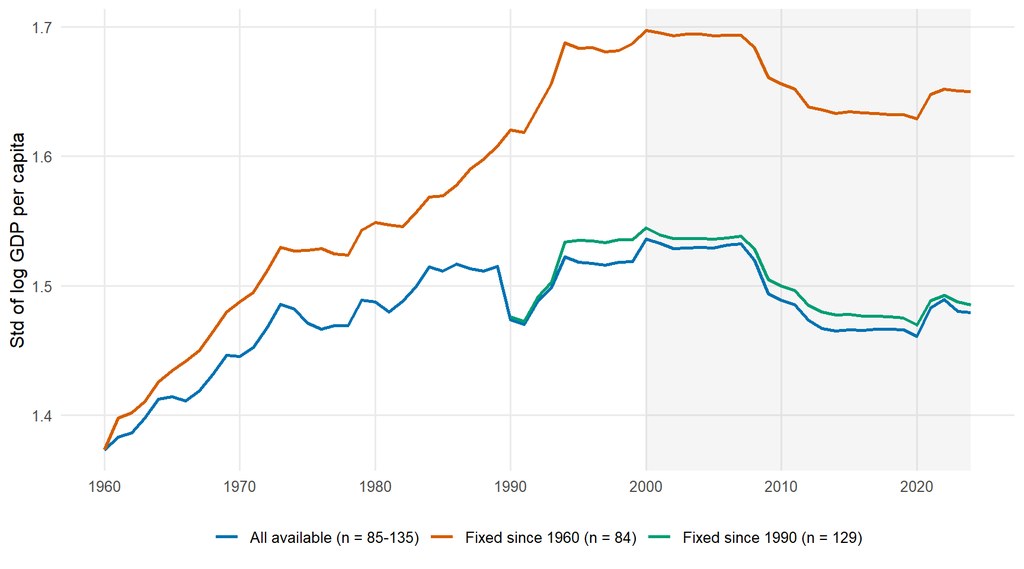

Figure 3: Cross-country standard deviation of log GDP per capita (constant 2015 US$), oil producers and countries under 1 million people excluded. Shaded: 2000-2024.

```r
ggplot(ss, aes(year, sigma, colour = sample)) +
  annotate("rect", xmin = 2000, xmax = 2024, ymin = -Inf, ymax = Inf, fill = "grey50", alpha = 0.08) +
  geom_line(linewidth = 0.9) +
  scale_colour_manual(values = c("#0072B2", "#D55E00", "#009E73"), name = NULL) +
  scale_x_continuous(breaks = seq(1960, 2020, 10)) +
  labs(x = NULL, y = "Std of log GDP per capita") +
  theme_minimal(base_size = 12) +
  theme(legend.position = "bottom", panel.grid.minor = element_blank())
```

**Code: draw bell curves of actual log GDP per capita in 1960, 1980, 2000 and 2024**

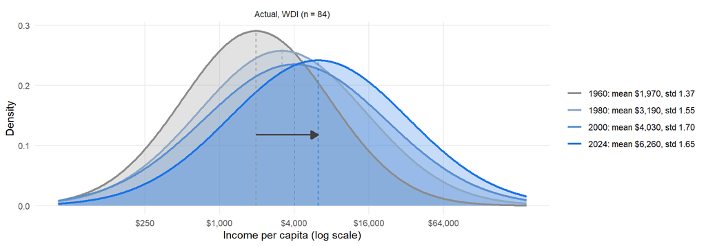

Figure 4: Distribution of log GDP per capita (constant 2015 US$) across the fixed 1960-2024 sample in 1960, 1980, 2000 and 2024. Normal density with each year’s mean and std; dashed: mean. The normal curve shows location and size only; the actual distribution is not bell-shaped (two humps after 1980; Quah 1996).

```r
b60 <- bal(1960)
sa <- b60[year %in% c(1960, 1980, 2000, 2024), .(mu = mean(ly), s = sd(ly)), keyby = year]
sa[, `:=`(panel = sprintf("Actual, WDI (n = %d)", uniqueN(b60$iso3)), when = factor(year))]
bell(sa, c(log(50), log(3e5)))
```

- The bell moves right and widens to 2000, then narrows slightly:
  - location, mean: $1,970 (1960) to $6,260 (2024);
  - size, std of log income: 1.37 (1960), 1.70 (2000), 1.65 (2024).

# Weak σ-convergence test

**TipKPS: does the cross-country variance trend down?**

- Intuition:
  - If incomes converge, their cross-section variance $K_t$ falls over time, perhaps slowly and noisily. KPS fit a straight line to $K_t$ and ask whether its slope is negative.
  - The line is deliberately misspecified (the true decay is a power law $t^{-\gamma}$), but the sign of the slope still picks up the direction of the trend (KPS Theorem 1, p. 15).
- Steps:
  1. Each year $t$, compute $K_t = n^{-1}\sum_i (y_{it} - \bar y_t)^2$.
  2. Regress $K_t = a + \varphi\,t + u_t$.
  3. Compute the t ratio of $\hat\varphi$ with a Newey-West HAC variance, $\lfloor T^{1/3}\rfloor$ lags.
  4. Weak σ-convergence if $t < -1.65$; σ-divergence if $t > 1.65$; otherwise no significant trend.
- Distribution of the t ratio (KPS Theorem 2, p. 18):
  - Under the null of neither convergence nor divergence (slope 0, variance only fluctuating), the t ratio is $N(0,1)$ by standard HAC theory, so one-sided normal critical values apply.
  - Under convergence it goes to $-\infty$ for slow decay; for very fast decay it stays bounded but its limit is about $-\sqrt3 = -1.73$, still below $-1.65$ (p. 19).
  - The scale of the variance cancels between numerator and denominator, so the limit is free of nuisance parameters (p. 19).
  - The convergence result needs $n/T \to \infty$ (more countries than years).
- Power: KPS simulate power with $T = 50$ (Fig. 3, p. 24): close to 1 away from the null, lower when convergence is very fast (few informative periods). Here $T$ is 25-65 (WDI) and 20 (PWT), so power is lower than in their simulations; I have not found results for $T = 20$ in the text read.

**Code: KPS weak σ-convergence test: variance on a linear trend, Newey-West t**

```r
fmt_p <- function(p) ifelse(p < 0.001, "<0.001", sprintf("%.3f", p))  # p-value display, used by all test tables
kps <- function(d, from, to, lab) {
  d <- d[year >= from & year <= to]
  m <- lm(K ~ year, data = d)
  L <- floor(nrow(d)^(1/3))
  se <- sqrt(sandwich::NeweyWest(m, lag = L, prewhite = FALSE)[2, 2])
  data.table(Sample = lab, Period = sprintf("%d-%d", from, to), T = nrow(d), Lags = L,
             `φ × 100` = sprintf("%.3f", 100 * coef(m)[2]), `t ratio` = sprintf("%.2f", coef(m)[2] / se),
             `p (one-sided)` = fmt_p(pnorm(coef(m)[2] / se)))
}
res <- rbind(kps(s_60, 1960, 2024, "Fixed since 1960"), kps(s_60, 1960, 1999, "Fixed since 1960"),
             kps(s_60, 2000, 2024, "Fixed since 1960"), kps(s_90, 1990, 2024, "Fixed since 1990"),
             kps(s_90, 2000, 2024, "Fixed since 1990"))
y <- tt(res, theme = "striped")
y <- style_tt(y, i = 0, background = "#e7f0fa")
style_tt(y, j = 3:7, align = "r")
```

Table 1: Trend regression K_t = a + φ t + u_t on the cross-section variance K_t of log GDP per capita; t ratio uses a Newey-West HAC variance with floor(T^(1/3)) lags. φ < 0 with t below -1.65 indicates weak σ-convergence (one-sided 5%).

| Sample | Period | T | Lags | φ × 100 | t ratio | p (one-sided) |
| --- | --- | --- | --- | --- | --- | --- |
| Fixed since 1960 | 1960-2024 | 65 | 4 | 1.264 | 5.88 | 1.000 |
| Fixed since 1960 | 1960-1999 | 40 | 3 | 2.317 | 26.43 | 1.000 |
| Fixed since 1960 | 2000-2024 | 25 | 2 | -0.978 | -4.88 | <0.001 |
| Fixed since 1990 | 1990-2024 | 35 | 3 | -0.418 | -1.96 | 0.025 |
| Fixed since 1990 | 2000-2024 | 25 | 2 | -0.955 | -5.96 | <0.001 |

- Reading: a negative $\varphi$ means cross-country variance is trending down over the period.
- The fixed samples avoid compositional change (countries entering the data), which moves the unbalanced series.

# Absolute β-convergence (WDI)

**Code: β-convergence regression on WDI: average growth on initial log income; implied λ and half-life**

```r
wbeta <- function(d, from, to, lab) {
  w <- dcast(d[year %in% c(from, to)], iso3 ~ year, value.var = "ly")
  setnames(w, c("iso3", "y0", "y1"))
  TT <- to - from
  w[, gr := (y1 - y0) / TT]                                       # average annual growth
  m <- lm(gr ~ y0, data = w)
  b <- -coef(m)[2]
  se <- sqrt(sandwich::vcovHC(m, type = "HC1")[2, 2])
  lam <- if (b > 0) -log(1 - b * TT) / TT else NA_real_
  data.table(Sample = lab, Period = sprintf("%d-%d", from, to), n = nrow(w),
             b = sprintf("%.5f", b), `s.e.` = sprintf("%.5f", se), `t ratio` = sprintf("%.2f", b / se),
             p = fmt_p(2 * pt(-abs(b / se), df = nrow(w) - 2)),
             `Half-life (years)` = if (is.na(lam)) "" else sprintf("%.0f", log(2) / lam))
}
b90 <- bal(1990)
wb <- rbind(wbeta(b60, 1960, 2024, "Fixed since 1960"), wbeta(b60, 1960, 1999, "Fixed since 1960"),
            wbeta(b60, 2000, 2024, "Fixed since 1960"), wbeta(b90, 1990, 2024, "Fixed since 1990"),
            wbeta(b90, 2000, 2024, "Fixed since 1990"))
y <- tt(wb, theme = "striped", width = 0.85)
y <- style_tt(y, i = 0, background = "#e7f0fa")
style_tt(y, j = 3:8, align = "r")
```

Table 2: Average annual growth of log GDP per capita (constant 2015 US$) on initial log GDP per capita; b = minus the slope (b > 0: β-convergence, b < 0: β-divergence); HC1 s.e.; λ = -ln(1 - bT)/T.

| Sample | Period | n | b | s.e. | t ratio | p | Half-life (years) |
| --- | --- | --- | --- | --- | --- | --- | --- |
| Fixed since 1960 | 1960-2024 | 84 | -0.00005 | 0.00102 | -0.05 | 0.961 |  |
| Fixed since 1960 | 1960-1999 | 84 | -0.00265 | 0.00132 | -2.01 | 0.048 |  |
| Fixed since 1960 | 2000-2024 | 84 | 0.00215 | 0.00090 | 2.39 | 0.019 | 314 |
| Fixed since 1990 | 1990-2024 | 129 | 0.00146 | 0.00085 | 1.72 | 0.088 | 462 |
| Fixed since 1990 | 2000-2024 | 129 | 0.00292 | 0.00081 | 3.61 | <0.001 | 229 |

- Reading: β moves with σ. Poorer countries grew more slowly in 1960-1999 (β-divergence) and faster in 2000-2024 (β-convergence), but catch-up is slow (half-life of 229-314 years, 2000-2024).

# PWT 10.01, 2000-2019: KPS and Phillips-Sul tests

Did cross-country income dispersion fall over 2000-2019?

**NoteExisting studies, tests and data**

- Existing studies
  - Lähdemäki (2024, abstract): σ-convergence of labour productivity “from the year 2000” for all countries.
  - Patel, Sandefur, and Subramanian (2021, 5): Find “no evidence of meaningful σ-convergence” of income per capita, with variance falling only after 2008.
- This note tests log income per capita
  1. Kong, Phillips, and Sul (2019) weak σ test on the raw cross-section variance.
  2. The same test after removing estimated common factors, as KPS recommend for trending panels (KPS p. 5; Sul slides 29, 32).
  3. Phillips and Sul (2007) log t test of relative convergence, which allows nonstationary income (PS p. 1773).
- Penn World Table 10.01
  - Series: `rgdpe / pop` (expenditure-side real GDP at chained PPPs, 2017 US$, per person), saved in `data/pwt1001.dta`; nothing is downloaded at render.
  - Sample: countries observed every year 2000-2019; oil producers and countries under 1 million people (PWT, 2019) excluded, as above.

**Code: load PWT 10.01, build the balanced 2000-2019 panel; define variance and KPS test functions**

```r
pwt <- as.data.table(haven::read_dta("data/pwt1001.dta"))[, .(iso3 = countrycode, year, rgdpe, pop)]
pwt <- pwt[year %in% 2000:2019 & !is.na(rgdpe) & !is.na(pop) & rgdpe > 0]
small_p <- pwt[year == 2019 & pop < 1, iso3]                    # PWT pop in millions
keep_p <- pwt[, .N, by = iso3][N == 20, iso3]                   # balanced 2000-2019
pwt <- pwt[iso3 %in% setdiff(keep_p, c(oil, small_p))]
pwt[, ly := log(rgdpe / pop)]
Y <- as.matrix(dcast(pwt, year ~ iso3, value.var = "ly")[, -1])  # T x n, rows 2000..2019
TT <- nrow(Y); n <- ncol(Y); yrs_p <- 2000:2019
# Cross-section variance K_t = n^-1 sum_i (y_it - mean_t)^2
Kfun <- function(M) apply(M, 1, function(r) mean((r - mean(r))^2))
# KPS trend test: K_t on a linear trend, Newey-West HAC t with floor(T^(1/3)) lags
kpsK <- function(K, lab) {
  tr <- seq_along(K); m <- lm(K ~ tr); L <- floor(length(K)^(1/3))
  se <- sqrt(sandwich::NeweyWest(m, lag = L, prewhite = FALSE)[2, 2])
  data.table(Series = lab, phi100 = 100 * coef(m)[2], t = coef(m)[2] / se, Lags = L)
}
```

- Sample size: 128 countries, 20 years.

## Absolute β-convergence in this sample

**Code: β-convergence regression 2000-2019: growth on initial log income; implied λ**

```r
g <- (Y[TT, ] - Y[1, ]) / (TT - 1)                              # average annual growth 2000-2019
mb <- lm(g ~ Y[1, ])
b  <- -coef(mb)[2]
lam <- -log(1 - b * (TT - 1)) / (TT - 1)                        # lambda = -ln(1 - bT)/T
bse <- sqrt(sandwich::vcovHC(mb, type = "HC1")[2, 2])
```

- Average growth 2000-2019 on log income in 2000: slope $-b$ with $b$ = 0.0039 (HC1 s.e. 0.0014), implying $\lambda$ = 0.0040 per year and a half-life of 172 years.
- Patel et al. report $\beta$ = .00425 (s.e. .00156) and a half-life of 170 years for 124 PWT countries, 2000-2019 (p. 5).
- β agrees with the literature: catch-up is real but slow (half-life near 170 years).

## Removing common factors

- Model: $y_{it} = c_i + \lambda_i' F_t + y^o_{it}$; the test is applied to $z_{it} = c_i + y^o_{it}$ (Sul slide 32).
- Estimation: principal components of the time-demeaned panel; $\hat F$ = first $k$ eigenvectors of $\tilde Y\tilde Y'$ scaled by $\sqrt T$, $\hat\lambda_i = \tilde Y_i'\hat F/T$.
- Number of factors: Bai-Ng $IC_2$ on standardised growth rates, $k_{\max}=5$.

**Code: choose the number of common factors (Bai-Ng IC2) and remove principal-component factors**

```r
Yt <- sweep(Y, 2, colMeans(Y))                                  # remove c_i
pc <- function(M, k) {                                          # principal-component factors
  e <- eigen(M %*% t(M), symmetric = TRUE)
  Fh <- sqrt(nrow(M)) * e$vectors[, 1:k, drop = FALSE]
  Lh <- t(M) %*% Fh / nrow(M)
  list(F = Fh, L = Lh, fit = Fh %*% t(Lh))
}
G <- scale(diff(Y)); Tg <- nrow(G)                              # Bai-Ng IC2 on standardised differences
ic2 <- sapply(1:5, function(k) {
  V <- mean((G - pc(G, k)$fit)^2)
  log(V) + k * (n + Tg) / (n * Tg) * log(min(n, Tg))
})
k_ic <- which.min(ic2)
Z <- lapply(1:3, function(k) Y - pc(Yt, k)$fit)                 # z = c_i + residual
```

- $IC_2$ selects $k$ = 1 (values for k = 1-5: -0.165, -0.158, -0.159, -0.163, -0.142).

## Phillips-Sul log t test

Test $b<0$ for nonconvergence

$$\ln\frac{\sigma^{2}_0}{\sigma^{2}_{t}} - 2\ln\ln(t+1) = a + b\ln t + u_t$$

**TipPhillips-Sul (1): intuition and steps**

- Intuition:
  - Any panel can be written as a common trend $\mu_t$ times a loading, $X_{it} = \delta_{it}\mu_t$(PS eq. 5, p. 1774).
    - This is an identity with $\delta_{it} \equiv X_{it}/\mu_t$, not an assumption.
    - Other group trends end up in $\delta_{it}$.
  - The restriction is on how $\delta_{it}$ moves: $\delta_{it} = \delta_i + \sigma_i\xi_{it}L(t)^{-1}t^{-\alpha}$ (PS eq. 3, p. 1773).
    - Group trends that drift apart make $\delta_{it}$ diverge across groups ⇒ the test rejects ⇒ clubs (PS’s wage example, eq. 7, p. 1776).
    - The specification $\delta_{it} = \delta_i + \sigma_i\xi_{it}L(t)^{-1}t^{-\alpha}$ is chosen by authors.
    - $L(t)$: a slowly varying function, $L(at)/L(t) \to 1$ as $t \to \infty$ for all $a > 0$ (PS fn. 3, p. 1781, page unverified), with $L(t) \to \infty$ (p. 1773), e.g. $\log t$. The test sets $L(t) = \log(t+1)$ (p. 1789).
  - Let each country’s log income relative to the cross-section mean as $h_{it} = X_{it}/(N^{-1}\sum_i X_{it})$, its cross-section variance as $H_t = N^{-1}\sum_i (h_{it}-1)^2$.
    - Mean of $h_{it}=N^{-1}\sum h_{it} = N^{-1}\sum X_{it}/(N^{-1}\sum_i X_{it})=1$
  - Convergence  
    ⇒ All loadings end up equal  
    ⇒ Each relative path $h_{it}$ (own log income divided by the cross-section mean) → 1  
    ⇒ their spread $H_t$ → 0.
  - When loadings converge at rate $t^{-\alpha}$, we can detect it with $b$ in $\ln\frac{H_1}{H_t} - 2\ln L(t) = a + b\ln t + u_t$ [ $\because$ $H_t$ shrinks like $1/(L(t)^2 t^{2\alpha})$ (PS eq. 34, p. 1789)]  
    ⇒
    - if actually converging, $\ln (H_1/H_t) -2\ln L(t)$ will cancel out the shrinkage, the coeff on $\ln t$ is $b = 2\alpha \geqslant 0$
    - if not, $\left\{\ln (H_1/H_t) -2\ln L(t)\right\}$↓, so $t_{\hat b} < -1.65$ (one-sided 5%; $\hat b$ itself may stay near 0, PS Thm 2(a), p. 1795)
- Steps (PS pp. 1788-1789):
  1. Relative transition path: $h_{it} = X_{it}/(n^{-1}\sum_i X_{it})$, each country’s log income relative to the cross-section mean.
  2. Its cross-section variance: $H_t = n^{-1}\sum_i (h_{it}-1)^2$.
  3. Drop the first fraction $r = 0.3$ of years: keep $t = \lfloor rT\rfloor, \dots, T$.
  4. Regress $\log(H_1/H_t) - 2\log L(t)$ on $\log t$, with $L(t) = \log(t+1)$.
  5. Compute the t ratio of the slope with a HAC variance (quadratic-spectral kernel; said to match the `ConvergenceClubs` package, unverified: the package is not installed).
  6. Reject convergence at 5% if $t < -1.65$ (one-sided).
- $X_{it}$: log income, HP-filtered with $\lambda = 400$ as in Sichera & Pizzuto (2019, pp. 146-147); also unfiltered.

**TipPhillips-Sul (2): derivation of the log t regression**

- Two sources of spread in $h_{it}$; write $s_t \equiv L(t)^{-1}t^{-\alpha}$ and $\psi_{it} \equiv \sigma_i\xi_{it}$ (PS eq. 60, p. 1817), with $s_{t}\rightarrow 0$ as $t\rightarrow\infty$:

  $$\begin{aligned}
  h_{it} - 1 &= \frac{\delta_i - \bar\delta + (\psi_{it} - \bar\psi_t)\,s_t}{\bar\delta + \bar\psi_t s_t} &&\text{(} \delta_i - \bar\delta\text{: permanent;}\\
  & &&\phantom{\text{(}}(\psi_{it} - \bar\psi_t)s_t\text{: transitory,}\\
  & &&\phantom{\text{(}}s_t \to 0)\\
  H_0\ (\delta_i = \delta,\ \alpha \geqslant 0):\quad h_{it} - 1 &= \frac{(\psi_{it} - \bar\psi_t)\,s_t}{\delta + \bar\psi_t s_t} \;\Rightarrow\; H_t \to 0 &&\text{(derived below;}\\
  & &&\phantom{\text{(}}\varepsilon_t \text{ is defined on this branch)}\\
  H_A\ (\delta_i \ne \delta,\ \alpha \geqslant 0):\quad h_{it} - 1 &\to \frac{\delta_i - \bar\delta}{\bar\delta} \;\Rightarrow\; H_t \to N^{-1}\textstyle\sum_i(\delta_i - \bar\delta)^2/\bar\delta^2 > 0 &&\text{(PS p. 1789: positive limit;}\\
  & &&\phantom{\text{(}}\text{the formula is my algebra)}\\
  H_A\ (\delta_i \ne \delta,\ \alpha < 0):\quad h_{it} - 1 &\to \frac{\psi_{it}}{\bar\psi_t}-1 \;\Rightarrow\; H_t \to \frac{\sigma_{\xi}^2}{N} > 0 &&\text{(loading deviations grow,}\\
  & &&\phantom{\text{(}}\text{PS p. 1788; $s_t \to \infty$)}
  \end{aligned}$$
- Under convergence, $\delta_i = \delta$ for all $i$:
  $$\begin{aligned}
  h_{it} &= \frac{\delta_{it}\mu_t}{N^{-1}\sum_j \delta_{jt}\mu_t} = \frac{\delta_{it}}{\bar\delta_t} &&\quad\text{(} X_{it} = \delta_{it}\mu_t\text{; } \mu_t \text{ cancels)}\\
  \delta_{it} &= \delta + \psi_{it}s_t,\qquad \bar\delta_t = \delta + \bar\psi_t s_t &&\quad\text{(eq. 3 with } \delta_i = \delta\text{; average over } i)\\
  h_{it} - 1 &= \frac{\delta_{it} - \bar\delta_t}{\bar\delta_t} = \frac{(\psi_{it} - \bar\psi_t)\,s_t}{\delta + \bar\psi_t s_t} &&\quad\text{(subtract the two lines above)}\\
  H_t &= N^{-1}\sum_i (h_{it}-1)^2 = \frac{s_t^2\,\sigma^2_{\psi t}}{(\delta + \bar\psi_t s_t)^2} &&\quad\text{(square, average over } i\text{; PS eq. 61)}\\
  &= \frac{s_t^2\,\sigma^2_{\psi t}}{\delta^2 + 2\delta\bar\psi_t s_t + \bar\psi_t^2 s_t^2} &&\quad\text{(expand the square)}\\
  &= \frac{s_t^2\,\sigma^2_{\psi t}}{\delta^2\,(1 + 2\bar\psi_t s_t/\delta + \bar\psi_t^2 s_t^2/\delta^2)} &&\quad\text{(factor out } \delta^2)\\
  &= \frac{s_t^2\,\sigma^2_{\psi t}}{\delta^2\,(1 + 2\lambda_t + \lambda_t^2)} &&\quad\text{(} \lambda_t \equiv \bar\psi_t s_t/\delta)\\
  &= \frac{s_t^2\,\sigma^2_{\psi t}}{\delta^2\,(1+\zeta_t)} &&\quad\text{(} \zeta_t \equiv \lambda_t^2 + 2\lambda_t\text{; PS eq. 66, p. 1819)}
  \end{aligned}$$
  - Notations

    $\sigma^2_{\psi t} \equiv N^{-1}\sum_i(\psi_{it}-\bar\psi_t)^2 = v^2 + N^{-1/2}\eta_{Nt} - N^{-1}\eta_{2Nt}$ (PS eq. 62): random each $t$, with mean $v^2 = N^{-1}(1-N^{-1})\sum_i\sigma_i^2$

    $\eta_{Nt}, \eta_{2Nt}$: mean-zero noise (PS p. 1818).

    $\zeta_t = (1+\lambda_t)^2 - 1$: how far $(\delta + \bar\psi_t s_t)^2$ is from $\delta^2$, as a share of $\delta^2$.

    $\zeta_t \to 0$ since $s_t \to 0$, which PS use to expand $\log(1+\zeta_t) = \zeta_t - \zeta_t^2/2 + \dots$ (PS p. 1819).
  - Every line is an identity. $H_t \to 0$ under convergence (PS p. 1789); taking logs turns the vanishing factor $s_t^2$ into the terms $-2\log L(t) - 2\alpha\log t \to -\infty$, which the regression on $\log t$ estimates.

    $$\begin{aligned}
    \log H_t &= \log s_t^2 + \log\frac{\sigma^2_{\psi t}}{\delta^2} - \log(1+\zeta_t) &&\quad\text{(take logs)}\\
    &= -2\log L(t) - 2\alpha\log t + \log\frac{\sigma^2_{\psi t}}{\delta^2} - \log(1+\zeta_t) &&\quad\text{(} s_t^2 = L(t)^{-2}t^{-2\alpha})\\
    &= -2\log L(t) - 2\alpha\log t + 2\log(v/\delta) + \varepsilon_t &&\quad\text{(PS eqs. 68-69; } \varepsilon_t \text{ below)}\\
    \log H_1 - \log H_t &= \log H_1 - 2\log(v/\delta) + 2\log L(t) + 2\alpha\log t - \varepsilon_t &&\quad\text{(subtract from } \log H_1)
    \end{aligned}$$

    Then we have the estimating equation:
    $$\log\frac{H_1}{H_t} - 2\log L(t) = a + b\log t + u_t$$

    $\varepsilon_t \equiv \log(\sigma^2_{\psi t}/v^2) - \log(1+\zeta_t)$; $a = \log H_1 - 2\log(v/\delta)$, $b = 2\alpha$, $u_t = -\varepsilon_t$ (p. 1789).
- Test of $b \geqslant 0$  
  ⇒ $t_{\hat b} \geqslant -1.65$: consistent with $H_t$ shrinking at least as fast as $L(t)^{-2}$ ⇒ convergence not rejected  
  ⇒ $t_{\hat b} < -1.65$: spread shrinks too slowly ⇒ convergence rejected (one-sided HAC t test, Step 3, p. 1789). $\hat b < 0$ alone does not reject.
- Penalty $-2\log L(t) = -2\log\log(t+1)$ (p. 1789); dependent variable $\log(H_1/H_t) - 2\log L(t)$ (eq. 36):
  - Under $H_0$ with $\alpha > 0$: $\log(H_1/H_t) = 2\log L(t) + 2\alpha\log t + O_p(1)$ (p. 1790) ⇒ $\hat b \to_p 2\alpha > 0$ ⇒ $t_{\hat b} \to +\infty$ ⇒ not rejected.
  - Under $H_0$ at its boundary $\alpha = 0$ (slowest convergence: only $L(t)^{-1}$ decays): $\log(H_1/H_t) = 2\log L(t) + O_p(1)$ ⇒ the penalty cancels it ⇒ $t_{\hat b} \Rightarrow N(0,1)$ (Thm 1(b), p. 1790): $\hat b < 0$ half the time, rejected 5% of the time (the test’s size).
  - $H_A$, Loadings never meet ($\delta_i \ne \delta$): $H_t \to$ positive constant (p. 1789) ⇒ $\log(H_1/H_t) = O_p(1)$ ⇒ $\log(H_1/H_t) - 2\log L(t) = -2\log L(t) + O_p(1) \to -\infty$ ⇒ LHS↓ $\sim$ RHS↑ $\hat b < 0$, $t_{\hat b} \to -\infty$ ⇒ rejected (p. 1790).
  - Without the penalty, both cases give $\hat b \to 0$ ($\log L(t)$ grows more slowly than $\log t$): the test could not tell them apart.
  - $O_p(1)$: a term that stays bounded in probability as $t \to \infty$.
- Fast convergence with nearly equal loadings: $\delta_i \sim \text{iid}(\delta, \kappa^2 T^{-2\omega})$ (PS eq. 41, p. 1796; PS write $c^2$ for $\kappa^2$) ⇒ permanent gap $|\delta_i - \delta| = O_p(T^{-\omega})$.
  - $\omega \leqslant \alpha$: $\hat b \to_p 0$, $t_{\hat b} \to -\infty$ ⇒ rejected (Thm 3(a), p. 1796); a larger $\alpha$ widens this range.
  - $\omega > \alpha$: $\hat b - b \to_p 0$ ⇒ behaves like $H_0$ (Thm 3(b), pp. 1796-1797).
- Why $\hat b \to_p 0$ when $\omega \leqslant \alpha$ (PS App. B, eqs. 99-103, pp. 1831-1832; eqs. 123-126, pp. 1842-1843):

  $$\begin{aligned}
  T_r &\equiv T - \lfloor rT\rfloor + 1 &&\quad\text{(number of } t \text{ in the window } \lfloor rT\rfloor, \dots, T)\\
  q &\equiv t/T \in [r, 1] &&\quad\text{(position of } t \text{ in the sample; } |\log q| \leqslant |\log r|)\\
  \tau_t &\equiv \log(t/T) - T_r^{-1}\textstyle\sum_{m=\lfloor rT\rfloor}^{T}\log(m/T) &&\quad\text{(} \log(t/T) \text{ minus its mean over the window; p. 1821)}\\
  &= \log t - \log T - T_r^{-1}\textstyle\sum_m \log m + \log T &&\quad\text{(} \log(x/T) = \log x - \log T\text{; } \textstyle\sum_m \log T = T_r\log T)\\
  &= \log t - T_r^{-1}\textstyle\sum_m \log m &&\quad\text{(} \log t \text{ minus its mean over the window; p. 1791)}\\
  \textstyle\sum_t \tau_t &= \textstyle\sum_t \log t - T_r\,T_r^{-1}\sum_m \log m = 0 &&\quad\text{(} \textstyle\sum_t \equiv \sum_{t=\lfloor rT\rfloor}^{T})
  \end{aligned}$$

  $$\begin{aligned}
  \log H_t &= 2\log(\kappa/\delta) - 2\omega\log T + \tilde\varepsilon_t &&\quad\text{(} \sigma_\delta^2 = \kappa^2T^{-2\omega} \text{ dominates;}\\
  & &&\quad\phantom{\text{(}}\text{eqs. 123, 125)}\\
  y_t \equiv \log\frac{H_1}{H_t} - 2\log L(t) &= C_T - 2\log L(t) - \tilde\varepsilon_t &&\quad\text{(eq. 124)}\\
  \hat b &= \frac{\sum_t \tau_t y_t}{\sum_t \tau_t^2} &&\quad\text{(OLS slope, centred regressor; eq. 99)}\\
  &= \frac{C_T\sum_t \tau_t - 2\sum_t \tau_t\log L(t) - \sum_t \tau_t\tilde\varepsilon_t}{\sum_t \tau_t^2} &&\quad\text{(substitute } y_t)\\
  &= -2\,\frac{\sum_t \tau_t\log L(t)}{\sum_t \tau_t^2} - \frac{\sum_t \tau_t\tilde\varepsilon_t}{\sum_t \tau_t^2} &&\quad\text{(} \textstyle\sum_t \tau_t = 0)
  \end{aligned}$$

  $C_T \equiv \log H_1 - 2\log(\kappa/\delta) + 2\omega\log T$: constant in $t$; $\tilde\varepsilon_t \to_p 0$ (eq. 125).

  $$\begin{aligned}
  \log L(t) &= \log(\log T + \log q) &&\quad\text{(} L(t) = \log t\text{, } t = qT)\\
  &= \log\log T + \log\Big(1 + \frac{\log q}{\log T}\Big) &&\quad\text{(factor out } \log T)\\
  &= \log\log T + \frac{\log q}{\log T} - \frac{\log^2 q}{2\log^2 T} + O\Big(\frac{1}{\log^3 T}\Big) &&\quad\text{(Taylor; } x = \log q/\log T \to 0\text{;}\\
  & &&\quad\phantom{\text{(}}\text{eq. 100)}\\
  \log q &= \tau_t + T_r^{-1}\textstyle\sum_m \log(m/T) &&\quad\text{(definition of } \tau_t)\\
  \textstyle\sum_t \tau_t\log q &= \textstyle\sum_t \tau_t^2 + T_r^{-1}\sum_m \log(m/T)\sum_t \tau_t = \sum_t \tau_t^2 &&\quad\text{(} \textstyle\sum_t \tau_t = 0)\\
  \frac{\sum_t \tau_t\log L(t)}{\sum_t \tau_t^2} &= \log\log T\,\frac{\sum_t \tau_t}{\sum_t \tau_t^2} &&\quad\text{(multiply } \log L(t) \text{ by } \tau_t\text{,}\\
  & &&\quad\phantom{\text{(}}\text{sum, divide)}\\
  &\quad + \frac{1}{\log T}\,\frac{\sum_t \tau_t\log q}{\sum_t \tau_t^2} &&\\
  &\quad - \frac{1}{2\log^2 T}\,\frac{\sum_t \tau_t\log^2 q}{\sum_t \tau_t^2} + O\Big(\frac{1}{\log^3 T}\Big) &&\\
  &= \frac{1}{\log T} - \frac{g(r)}{2\log^2 T} + O\Big(\frac{1}{\log^3 T}\Big) &&\quad\text{(lines above;}\\
  & &&\quad\phantom{\text{(}}\text{last ratio} \to g(r)\text{; eq. 102)}\\
  \hat b &= -\frac{2}{\log T} + \frac{g(r)}{\log^2 T} - \frac{\sum_t \tau_t\tilde\varepsilon_t}{\sum_t \tau_t^2} + O_p\Big(\frac{1}{\log^3 T}\Big) \to_p 0 &&\quad\text{(substitute into } \hat b\text{; eq. 103)}
  \end{aligned}$$
  - $g(r)$: a constant that depends only on $r$ (p. 1832). The $-2/\log T$ is $\sum_t \tau_t\log q/\sum_t \tau_t^2 = 1$ scaled by $1/\log T$ (expansion of $\log L(t)$) and by $-2$ (penalty). $s_{\hat b}$ shrinks faster, so $t_{\hat b} \to -\infty$ (Remark 11, p. 1797).

**TipPhillips-Sul (3): link to the growth model**

(PS eq. 6 and the lines after it, p. 1775):

$$\begin{aligned}
\log y_{it} &= \log y_i^{*} + (\log y_{i0} - \log y_i^{*})e^{-\beta_{it}} + \log A_{it} = a_{it} + \log A_{it} &&\quad\text{(Solow path plus technology;}\\
& &&\quad\phantom{\text{(}}a_{it}\text{: transition part)}\\
\log A_{it} &= \log A_{i0} + \gamma_{it}\log A_t &&\quad\text{(} \gamma_{it}\text{: distance to frontier technology } A_t)\\
\log A_t &= a\,t &&\quad\text{(frontier grows at rate } a)\\
\log y_{it} &= a_{it} + \log A_{i0} + \gamma_{it}\,a\,t &&\quad\text{(substitute the two lines above)}\\
&= \frac{a_{it} + \log A_{i0} + \gamma_{it}\,a\,t}{a\,t}\cdot a\,t = \delta_{it}\mu_t &&\quad\text{(multiply and divide by } \mu_t = a\,t)
\end{aligned}$$

- $\delta_{it}\mu_t$ is one way to write log income in PS’s factor form $X_{it} = \delta_{it}\mu_t$ (eq. 5), with $\mu_t = a\,t$ chosen as the common component; PS: “corresponding to (5) and $\delta_{it}$ may be modeled according to (3)” (p. 1776).
  - The split is chosen, not identified (see the normalisation bullet below).
  - It gives $\delta_{it}$ an economic meaning; the test itself uses only $\delta_{it}/\bar\delta_t$, which does not depend on the split.
- What $\delta_{it}$ is made of, and its limit:

  $$\begin{aligned}
  \delta_{it} &= \frac{a_{it}}{a\,t} + \frac{\log A_{i0}}{a\,t} + \gamma_{it} &&\quad\text{(split the fraction)}\\
  |a_{it}| &\leqslant |\log y_i^{*}| + |\log y_{i0} - \log y_i^{*}| &&\quad\text{(} \beta_{it} \geqslant 0 \Rightarrow 0 < e^{-\beta_{it}} \leqslant 1\text{; a fixed number)}\\
  \delta_{it} &\to 0 + 0 + \lim_{t\to\infty}\gamma_{it} &&\quad\text{(fixed numbers } a_{it}, \log A_{i0} \text{ divided by } a\,t \to \infty)
  \end{aligned}$$
- $\delta_{it} \to \delta$ for all $i$ ⇔ $\gamma_{it} \to \gamma$ for all $i$: technology gaps settle at a common value.
- Steady states $y_i^{*}$ and initial technology $A_{i0}$ may differ across countries: they are divided by $a\,t$ and drop out.
- Hence relative, not level, convergence: let $\gamma_{it} = \gamma_{jt} \to \gamma$ and $\beta_{it} \to \infty$ (transitions end), and write $c_{it} \equiv a_{it} + \log A_{i0}$:

  $$\begin{aligned}
  \log y_{it} - \log y_{jt} &= c_{it} - c_{jt} \to (\log y_i^{*} + \log A_{i0}) - (\log y_j^{*} + \log A_{j0}) &&\quad\text{(} \gamma\,a\,t \text{ cancels; a constant gap)}\\
  \frac{\delta_{it}}{\delta_{jt}} &= \frac{c_{it}/(a\,t) + \gamma_{it}}{c_{jt}/(a\,t) + \gamma_{jt}} \to \frac{0 + \gamma}{0 + \gamma} = 1 &&\quad\text{(needs } \gamma \ne 0)\\
  \frac{\delta_{it}}{\delta_{jt}} &= \frac{c_{it}}{c_{jt}} \to \frac{\log y_i^{*} + \log A_{i0}}{\log y_j^{*} + \log A_{j0}} &&\quad\text{(if } \gamma_{it} = \gamma_{jt} = 0\text{: } a\,t \text{ cancels;}\\
  & &&\quad\phantom{\text{(}}\text{generally} \ne 1)
  \end{aligned}$$
- $\mu_t = a\,t$ is a normalisation, not identified: for any common rescaling factor $k_t \ne 0$ (same for all $i$), $X_{it} = \delta_{it}\mu_t = (\delta_{it}k_t)(\mu_t/k_t)$.
  - Only the common part of the $1/(a\,t)$ terms can move into $\mu_t$; the country-specific part $c_{it} - \bar c_t$, with $\bar c_t \equiv N^{-1}\sum_j c_{jt}$, stays in $\delta_{it}$. It is at most an analogy to PS’s $\sigma_i\xi_{it}L(t)^{-1}t^{-\alpha}$ (eq. 3): $c_{it} - \bar c_t$ is a deterministic country effect, nearly constant over $t$, while $\xi_{it}$ is mean-zero noise, weakly dependent over $t$ (p. 1773) (my reading).
  - The test is unaffected with any choice of multiplicative term $k_{t}$ with $\mu_{t}$ being one such choice: $h_{it} = (\delta_{it}k_t)/(\bar\delta_t k_t) = \delta_{it}/\bar\delta_t$ (eq. 32).

**Code: HP-filter log income; Phillips-Sul log t test on filtered and raw series**

```r
hp <- function(x, lambda = 400) {                               # Hodrick-Prescott trend
  Tn <- length(x); D <- diff(diag(Tn), differences = 2)
  as.vector(solve(diag(Tn) + lambda * crossprod(D), x))
}
logt <- function(X, lab, r = 0.3) {
  h <- X / rowMeans(X); H <- rowMeans((h - 1)^2)
  t0 <- max(floor(r * nrow(X)), 1); tr <- t0:nrow(X)
  dep <- log(H[1] / H[tr]) - 2 * log(log(tr + 1))
  m <- lm(dep ~ log(tr))
  se <- sqrt(sandwich::kernHAC(m, kernel = "Quadratic Spectral", prewhite = FALSE)[2, 2])
  list(H = H, res = data.table(Series = lab, b = coef(m)[2], t = coef(m)[2] / se, `First t` = t0, Obs = length(tr)))
}
Xhp <- apply(Y, 2, hp)
ps_hp  <- logt(Xhp, "log income, HP-filtered (λ = 400)")
ps_raw <- logt(Y,   "log income, unfiltered")
```

## Results

**Code: plot the cross-section variance, raw and after removing 1-3 factors**

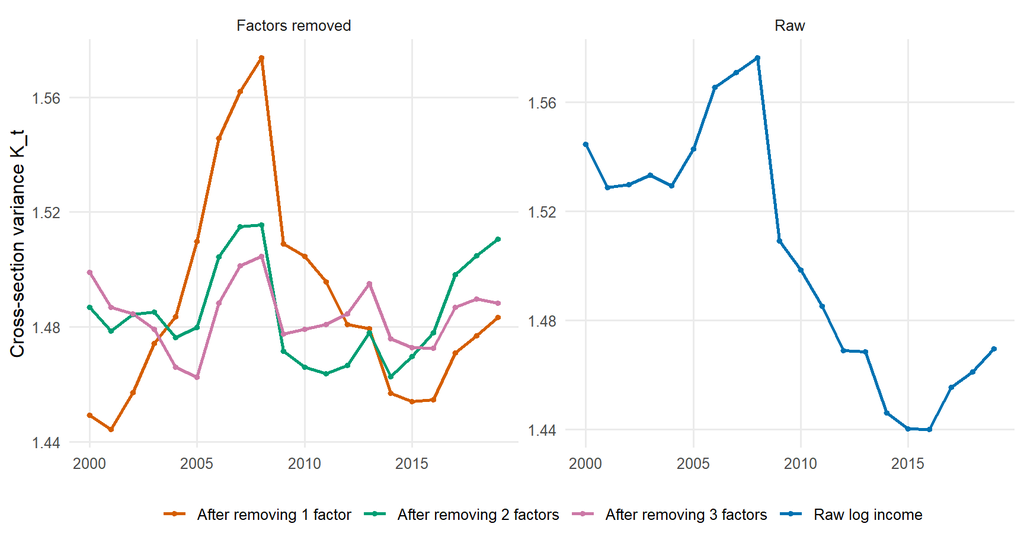

Figure 5: Cross-section variance of log real GDP per capita (PWT 10.01, rgdpe/pop), balanced 2000-2019 sample; raw and after removing k principal-component factors (country means kept).

```r
kd <- rbind(data.table(year = yrs_p, K = Kfun(Y), Series = "Raw log income"),
            rbindlist(lapply(1:3, function(k) data.table(year = yrs_p, K = Kfun(Z[[k]]),
                                                         Series = sprintf("After removing %d factor%s", k, ifelse(k > 1, "s", ""))))))
ggplot(kd, aes(year, K, colour = Series)) +
  geom_line(linewidth = 0.9) + geom_point(size = 1.2) +
  facet_wrap(~ Series == "Raw log income", scales = "free_y", labeller = as_labeller(c(`TRUE` = "Raw", `FALSE` = "Factors removed"))) +
  scale_colour_manual(values = c("#D55E00", "#009E73", "#CC79A7", "#0072B2"), name = NULL) +
  labs(x = NULL, y = "Cross-section variance K_t") +
  theme_minimal(base_size = 12) +
  theme(legend.position = "bottom", panel.grid.minor = element_blank())
```

**Code: tabulate the KPS test, raw and after factor removal**

```r
res_k <- rbind(kpsK(Kfun(Y), "Raw log income"),
               rbindlist(lapply(1:3, function(k) kpsK(Kfun(Z[[k]]), sprintf("After removing %d factor%s%s", k,
                 ifelse(k > 1, "s", ""), ifelse(k == k_ic, " (IC2 choice)", ""))))))
res_k_show <- res_k[, .(Series, `φ × 100` = sprintf("%.4f", phi100), t = sprintf("%.2f", t), `p (one-sided)` = fmt_p(pnorm(t)), Lags)]
y1 <- tt(res_k_show, theme = "striped"); y1 <- style_tt(y1, i = 0, background = "#e7f0fa")
style_tt(y1, j = 2:5, align = "r")
```

Table 3: KPS weak σ-convergence test, PWT 2000-2019: K_t = a + φ t + u_t; Newey-West HAC t (floor(T^(1/3)) lags). Weak σ-convergence if t < -1.65.

| Series | φ × 100 | t | p (one-sided) | Lags |
| --- | --- | --- | --- | --- |
| Raw log income | -0.6183 | -5.29 | <0.001 | 2 |
| After removing 1 factor (IC2 choice) | -0.0567 | -0.32 | 0.376 | 2 |
| After removing 2 factors | 0.0150 | 0.20 | 0.581 | 2 |
| After removing 3 factors | -0.0087 | -0.20 | 0.422 | 2 |

- Raw log income: weak σ-convergence over 2000-2019 (Table 3, t = -5.29), but Figure 5 shows the variance rising until 2008 and falling afterwards. This reconciles the two claims: the linear-trend test (as in Lähdemäki) reports convergence over the whole window; the path (as in Patel et al.) shows the decline only after 2008.
- After removing 1-3 common factors: no significant trend. The decline in raw dispersion is carried by heterogeneous loadings on common factors, not by the idiosyncratic components.

**Code: tabulate the Phillips-Sul log t test**

```r
res_p <- rbind(ps_hp$res, ps_raw$res)
res_p_show <- res_p[, .(Series, b = sprintf("%.3f", b), t = sprintf("%.2f", t), `p (one-sided)` = fmt_p(pnorm(t)), `First t`, Obs)]
y2 <- tt(res_p_show, theme = "striped"); y2 <- style_tt(y2, i = 0, background = "#e7f0fa")
style_tt(y2, j = 2:6, align = "r")
```

Table 4: Phillips-Sul log t test, PWT 2000-2019 (r = 0.3). Relative convergence is rejected at 5% if t < -1.65.

| Series | b | t | p (one-sided) | First t | Obs |
| --- | --- | --- | --- | --- | --- |
| log income, HP-filtered (λ = 400) | -0.610 | -33.84 | <0.001 | 6 | 15 |
| log income, unfiltered | -0.579 | -30.06 | <0.001 | 6 | 15 |

**Code: plot the Phillips-Sul H_t, HP-filtered and unfiltered**

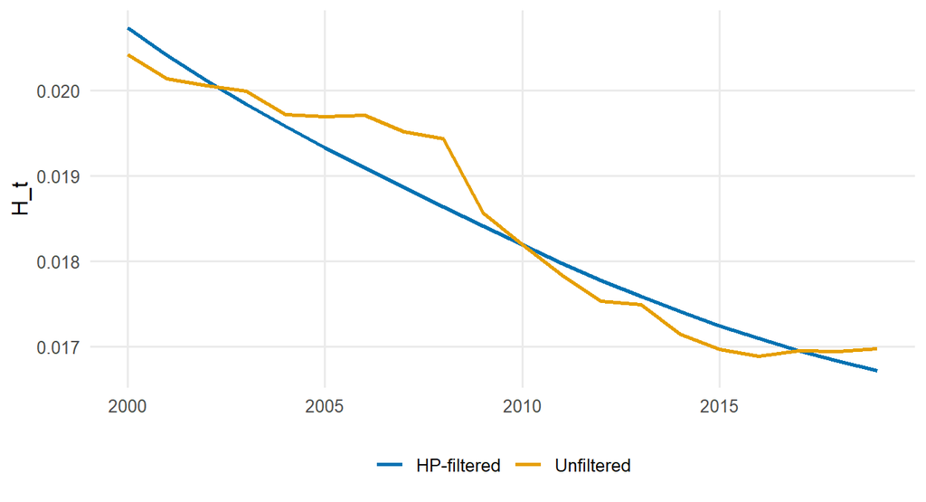

Figure 6: Phillips-Sul H_t: cross-section variance of relative transition paths h_it (log income relative to the cross-section mean), 2000-2019.

```r
hd <- rbind(data.table(year = yrs_p, H = ps_hp$H, Series = "HP-filtered"), data.table(year = yrs_p, H = ps_raw$H, Series = "Unfiltered"))
ggplot(hd, aes(year, H, colour = Series)) + geom_line(linewidth = 0.9) +
  scale_colour_manual(values = c("#0072B2", "#E69F00"), name = NULL) +
  labs(x = NULL, y = "H_t") + theme_minimal(base_size = 12) +
  theme(legend.position = "bottom", panel.grid.minor = element_blank())
```

- Phillips-Sul: $H_t$ falls (Figure 6), yet relative convergence is rejected (Table 4, t = -33.84 HP-filtered). The test asks $H_t$ to fall at least as fast as $L(t)^{-2}$ (PS p. 1789); here $\log(H_1/H_T)$ = 0.215, too slow over 20 years.

## Club convergence (exploratory)

- Low weight: clubs are formed by failing to reject convergence with only 15 regression points, so membership mostly reflects low power (see Caveats). Details are folded below.

**CautionClub convergence details (Phillips-Sul 2007, 2009), low power**

- When the log t test rejects for the whole panel, PS cluster countries into convergence clubs (steps from Sichera & Pizzuto 2019, pp. 144-145):
  1. Sort countries by the last observation (HP-filtered log income in 2019), richest first.
  2. Core group: the first $k$ countries, with $k^{*} = \arg\max_k t_k$ subject to $t_k > -1.65$; if the first two fail, drop the first country and retry.
  3. Sieve: add each remaining country whose log t with the core exceeds $c^{*} = 0$ (PS suggestion for $T < 50$); raise $c^{*}$ if the club as a whole fails.
  4. Repeat on the countries left over; if no core forms, they diverge.
  5. Merge adjacent clubs when their joint log t exceeds $-1.65$ (PS 2009).
- Implemented directly below (the `ConvergenceClubs` package is not installed); not validated against that package.

**Code: Phillips-Sul club clustering: core groups, club membership, merging**

```r
logt_t <- function(X, idx, r = 0.3) {                           # log t statistic for columns idx
  Xs <- X[, idx, drop = FALSE]
  h <- Xs / rowMeans(Xs); H <- rowMeans((h - 1)^2)
  t0 <- max(floor(r * nrow(Xs)), 1); tr <- t0:nrow(Xs)
  dep <- log(H[1] / H[tr]) - 2 * log(log(tr + 1))
  m <- lm(dep ~ log(tr))
  unname(coef(m)[2] / sqrt(sandwich::kernHAC(m, kernel = "Quadratic Spectral", prewhite = FALSE)[2, 2]))
}
core_group <- function(X, ord) {                                # step 2
  while (length(ord) >= 2) {
    if (logt_t(X, ord[1:2]) > -1.65) {
      tk <- numeric(0)
      for (k in 2:length(ord)) { tk_k <- logt_t(X, ord[1:k]); if (tk_k <= -1.65) break; tk <- c(tk, tk_k) }
      return(ord[1:(which.max(tk) + 1)])
    }
    ord <- ord[-1]
  }
  NULL
}
find_clubs <- function(X, cstar = 0) {                          # steps 1-4
  ord <- order(X[nrow(X), ], decreasing = TRUE); clubs <- list()
  repeat {
    if (length(ord) < 2) break
    if (logt_t(X, ord) > -1.65) { clubs[[length(clubs) + 1]] <- ord; ord <- integer(0); break }
    core <- core_group(X, ord); if (is.null(core)) break
    cs <- cstar
    repeat {
      rest <- setdiff(ord, core)
      add <- rest[vapply(rest, function(j) logt_t(X, c(core, j)) > cs, logical(1))]
      club <- c(core, add)
      if (logt_t(X, club) > -1.65 || length(add) == 0) break
      cs <- cs + 0.1
    }
    clubs[[length(clubs) + 1]] <- club[order(match(club, ord))]
    ord <- setdiff(ord, club)
  }
  list(clubs = clubs, divergent = ord)
}
merge_clubs <- function(X, clubs) {                             # step 5
  out <- list(); i <- 1
  while (i <= length(clubs)) {
    cur <- clubs[[i]]; j <- i + 1
    while (j <= length(clubs) && logt_t(X, c(cur, clubs[[j]])) > -1.65) { cur <- c(cur, clubs[[j]]); j <- j + 1 }
    out[[length(out) + 1]] <- cur; i <- j
  }
  out
}
fc <- find_clubs(Xhp)
mc <- merge_clubs(Xhp, fc$clubs)
nm <- unique(as.data.table(haven::read_dta("data/pwt1001.dta"))[, .(iso3 = countrycode, country)])
club_tab <- rbindlist(lapply(seq_along(mc), function(k) {
  iso <- colnames(Y)[mc[[k]]]
  lt <- logt_t(Xhp, mc[[k]])
  data.table(Club = as.character(k), n = length(iso), `log t` = sprintf("%.2f", lt), `p (one-sided)` = fmt_p(pnorm(lt)),
             `Mean income 2019 (2017 US$)` = format(round(mean(exp(Y[TT, mc[[k]]])), -2), big.mark = ","),
             Countries = paste(sort(nm[match(iso, iso3), country]), collapse = "; "))
}))
if (length(fc$divergent)) club_tab <- rbind(club_tab, data.table(Club = "Divergent", n = length(fc$divergent), `log t` = "", `p (one-sided)` = "",
  `Mean income 2019 (2017 US$)` = format(round(mean(exp(Y[TT, fc$divergent])), -2), big.mark = ","),
  Countries = paste(sort(nm[match(colnames(Y)[fc$divergent], iso3), country]), collapse = "; ")))
```

- Initial clubs: 12 (sizes 2, 17, 10, 21, 29, 14, 8, 12, 3, 4, 2, 2); after merging: 6; divergent: 4.

**Code: tabulate the convergence clubs and their members**

```r
y3 <- tt(club_tab, theme = "striped", width = c(0.08, 0.04, 0.06, 0.07, 0.11, 0.64))
y3 <- style_tt(y3, i = 0, background = "#e7f0fa")
y3 <- style_tt(y3, fontsize = 0.85)
y3 <- style_tt(y3, j = 6, align = "l")
style_tt(y3, j = 2:5, align = "r")
```

Table 5: Phillips-Sul convergence clubs after merging, PWT 10.01 income per capita (HP-filtered log), 2000-2019. log t > -1.65: convergence within the club not rejected.

| Club | n | log t | p (one-sided) | Mean income 2019 (2017 US$) | Countries |
| --- | --- | --- | --- | --- | --- |
| 1 | 50 | -0.93 | 0.176 | 38,000 | Argentina; Armenia; Australia; Austria; Belarus; Belgium; Bulgaria; Canada; Chile; China; China, Hong Kong SAR; Croatia; Czech Republic; Denmark; Estonia; Finland; France; Georgia; Germany; Hungary; I… |
| 2 | 29 | 2.61 | 0.996 | 14,500 | Albania; Bolivia (Plurinational State of); Bosnia and Herzegovina; Botswana; Brazil; Colombia; Costa Rica; Dominican Republic; Ecuador; Egypt; El Salvador; Greece; India; Jordan; Lebanon; Mauritius; M… |
| 3 | 22 | 7.59 | 1.000 | 5,600 | Bangladesh; Cambodia; Côte d'Ivoire; Eswatini; Ethiopia; Ghana; Guatemala; Honduras; Jamaica; Kenya; Kyrgyzstan; Morocco; Nepal; Nicaragua; Pakistan; Philippines; State of Palestine; Sudan; Syrian Ara… |
| 4 | 15 | -0.83 | 0.203 | 2,400 | Benin; Burkina Faso; Cameroon; Chad; Gambia; Guinea; Lesotho; Liberia; Mali; Rwanda; Senegal; Sierra Leone; Togo; U.R. of Tanzania: Mainland; Zimbabwe |
| 5 | 6 | 2.78 | 0.997 | 1,300 | D.R. of the Congo; Guinea-Bissau; Haiti; Madagascar; Malawi; Niger |
| 6 | 2 | 8.74 | 1.000 | 900 | Burundi; Central African Republic |
| Divergent | 4 |  |  | 19,800 | Mauritania; Mozambique; Switzerland; Uganda |

**Code: plot each club average relative transition path**

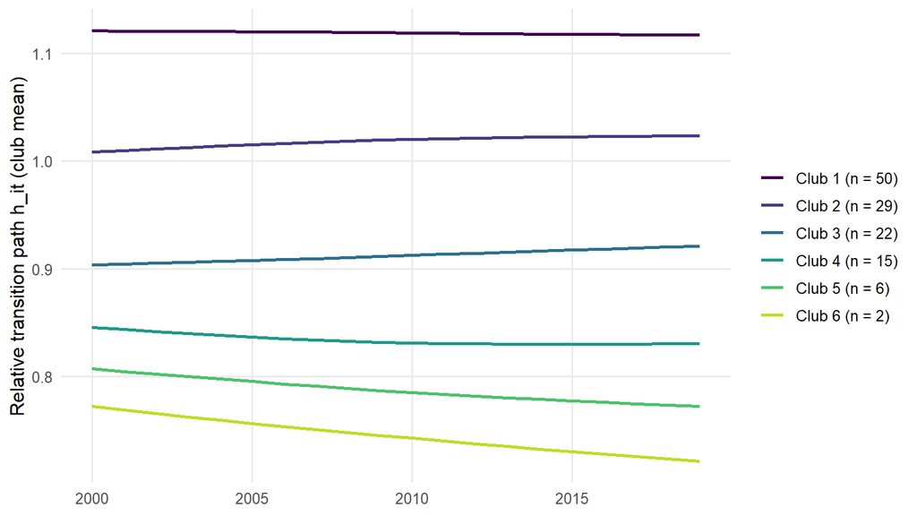

Figure 7: Average relative transition path of each club: club mean of h_it (HP-filtered log income relative to the cross-country mean), 2000-2019.

```r
hm <- Xhp / rowMeans(Xhp)
cp <- rbindlist(lapply(seq_along(mc), function(k) data.table(year = yrs_p, h = rowMeans(hm[, mc[[k]], drop = FALSE]),
                                                             Club = sprintf("Club %d (n = %d)", k, length(mc[[k]])))))
ggplot(cp, aes(year, h, colour = Club)) + geom_line(linewidth = 1) +
  scale_colour_viridis_d(end = 0.9, name = NULL) +
  labs(x = NULL, y = "Relative transition path h_it (club mean)") +
  theme_minimal(base_size = 12) + theme(legend.position = "right", panel.grid.minor = element_blank())
```

- Clubs: the whole panel does not converge, and convergence is not rejected within 6 groups (Table 5). Not rejecting is weak evidence here; the grouping is suggestive of Quah’s convergence clubs (Twin Peaks DP, p. 9), not a test of them.
- Club 1 is not a club of rich countries: it runs from Laos (2019 income $7,359, rank 82 of 128) to $102,354. It is initial clubs 1-4 (2 + 17 + 10 + 21 = 50 countries) merged because their joint log t (−0.93) is above −1.65. Read it as “paths not statistically separable over 2000-2019”. Laos enters through very fast growth (7.5% a year vs a median of 3.0%), which bends its relative path upward.

## Caveats

- Removing common factors with heterogeneous loadings can absorb catch-up itself: if poorer countries load more heavily on a common growth factor, convergence sits in $\lambda_i'F_t$ and is removed with it. The factor-removed rows test σ-convergence of the idiosyncratic component, not of income.
- PS log t tests relative convergence ($h_{it}\to 1$); with trending data this does not imply weak σ-convergence (KPS p. 7). With $T = 20$ and $r = 0.3$ the regression uses 15 years.
- $H_t$ is $K_t$ scaled by the squared mean of log income: $h_{it} - 1 = (y_{it}-\bar y_t)/\bar y_t$, so $H_t = K_t/\bar y_t^2$ (here 0.02042 in 2000 and 0.01698 in 2019, equal to $K_t/\bar y_t^2$).
  - $\bar y_t$ rose from 8.698 to 9.304, so $\bar y_t^2$ rose by $(9.304/8.698)^2 = 1.144$; $K_t$ fell by $1.4696/1.5446 = 0.951$.
  - $H_t$ fell to $0.951/1.144 = 0.831$ of its 2000 value: most of the 16.9% fall comes from rising mean log income, not from incomes moving together. $H_t$ also depends on the units of income (dollars vs thousands of dollars change $\bar y_t$).
- Power: PS report test size near nominal (the 5% test rejects 5% of the time when it should not) for $NT \geqslant 50$ and $r \geqslant 0.3$, and power falls as $r$ rises “because the effective sample size is smaller” (p. 1802). With 15 regression points, failing to reject is weak evidence. This matters for clubs, which are formed by non-rejection.
- Club membership depends on the core-group rule, $c^{*}$ and the merging rule (Sichera & Pizzuto 2019, p. 144); the clustering here is a direct implementation, not checked against `ConvergenceClubs`.
- HP filtering with $\lambda = 400$ on 20 annual observations has end-point effects.

## References

Kong, Jianning, Peter C. B. Phillips, and Donggyu Sul. 2019. “Weak σ-Convergence: Theory and Applications.” *Journal of Econometrics* 209 (2): 185–207. https://doi.org/10.1016/j.jeconom.2018.12.022.

Lähdemäki, Sakari. 2024. “Cross-Country Convergence: To Be or Not to Be, That Is the Question: S. Lähdemäki.” *Empirical Economics* 67 (2): 839–75.

Patel, Dev, Justin Sandefur, and Arvind Subramanian. 2021. “The New Era of Unconditional Convergence.” *Journal of Development Economics* 152: 102687. https://doi.org/10.1016/j.jdeveco.2021.102687.

Phillips, Peter C. B., and Donggyu Sul. 2007. “Transition Modeling and Econometric Convergence Tests.” *Econometrica* 75 (6): 1771–1855. https://doi.org/https://doi.org/10.1111/j.1468-0262.2007.00811.x.